# Modeling and prediction for movies

## Setup

### Load packages

```r
library(ggplot2)
library(dplyr)
library(statsr)
library(GGally)
```

### Load data

```r
load("movies.Rdata")
head(movies)
```

```
## # A tibble: 6 x 32
##   title title_type genre runtime mpaa_rating studio thtr_rel_year thtr_rel_month
##   <chr> <fct>      <fct>   <dbl> <fct>       <fct>          <dbl>          <dbl>
## 1 Fill… Feature F… Drama      80 R           Indom…          2013              4
## 2 The … Feature F… Drama     101 PG-13       Warne…          2001              3
## 3 Wait… Feature F… Come…      84 R           Sony …          1996              8
## 4 The … Feature F… Drama     139 PG          Colum…          1993             10
## 5 Male… Feature F… Horr…      90 R           Ancho…          2004              9
## 6 Old … Documenta… Docu…      78 Unrated     Shcal…          2009              1
## # … with 24 more variables: thtr_rel_day <dbl>, dvd_rel_year <dbl>,
## #   dvd_rel_month <dbl>, dvd_rel_day <dbl>, imdb_rating <dbl>,
## #   imdb_num_votes <int>, critics_rating <fct>, critics_score <dbl>,
## #   audience_rating <fct>, audience_score <dbl>, best_pic_nom <fct>,
## #   best_pic_win <fct>, best_actor_win <fct>, best_actress_win <fct>,
## #   best_dir_win <fct>, top200_box <fct>, director <chr>, actor1 <chr>,
## #   actor2 <chr>, actor3 <chr>, actor4 <chr>, actor5 <chr>, imdb_url <chr>,
## #   rt_url <chr>
```

## Part 1: Data

### Context of the study

This project is based on a fictitious scenario - one where I’ve been hired as a data scientist at Paramount pictures. The data, sourced by Paramount, presents numerous variables on movies such as audience and critic ratings. Paramount endeavors to gather insights into determining the acclaim of a film and other novel patterns or ideas. The data set is comprised of 651 randomly sampled movies produced and released before 2016.

### Sampling Design

```r
movies$studio %>%
  unique() %>%
  head(10)
```

```
##  [1] Indomina Media Inc.      Warner Bros. Pictures    Sony Pictures Classics
##  [4] Columbia Pictures        Anchor Bay Entertainment Shcalo Media Group
##  [7] Paramount Home Video     MGM/United Artists       Independent Pictures
## [10] IFC Films
## 211 Levels: 20th Century Fox ... Zeitgeist Films
```

```r
movies %>%
  summarise(max_year = max(thtr_rel_year), min_year = min(thtr_rel_year))
```

```
## # A tibble: 1 x 2
##   max_year min_year
##      <dbl>    <dbl>
## 1     2014     1970
```

Some of the film studios in the dataset are Indomina Media Inc., Warner Bros. Pictures, and Columbia Pictures. The majority of these studios are based in the US, and since the date ranges between the years 2014 and 1970. Most of these film studios, including ones by Sony Corporation, headquartered in Tokyo, are shot in California [^1]. Furthermore, US-based film studios were inexperienced in film productions abroad and often sold the rights to their films to foreign parties [^2]. It is thereby safe to assume such studios targeted a US-based audience. However, it should be noted that ratings produced by rotten tomatoes and IMDb tend to be based on a global audience.

### Scope of Inference

The data collected is observational and captures all the significant factors of a movie such as its genre, runtime, and whether or not the movie is in the Top 200 Box Office list on BoxOfficeMojo. Furthermore, The data is also a random sample of the movies. Since no strata, blocks, quotas, nor clusters are defined, a simple random sample can be assumed. Since this data does not result from an experimentation study, nor are there any variables that are blocked nor controlled, we cannot infer causation from the data.

### Generalizability

```r
year_n_movies <- movies %>%
  group_by(thtr_rel_year) %>%
  summarize(n_movies = n())
```

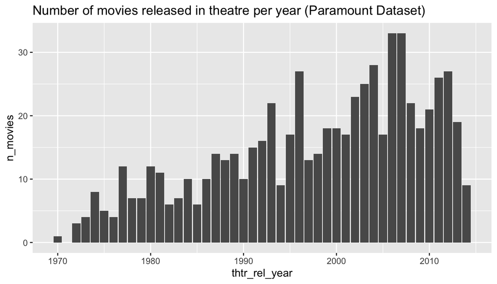

```r
ggplot(data = year_n_movies, aes(x = thtr_rel_year, y = n_movies)) +
  geom_bar(stat='identity') +
  ggtitle("Number of movies released in theatre per year (Paramount Dataset)")
```

As according to the bar graph above, over 50% of the years have below 20 movies. Therefore, we cannot generalize these results to all U.S. movies released in each year. However, we can generalize this to a random sample of all U.S. movies as the dataset consists of 651. This is well below 10% of all movies released in the U.S. and it is a random sample, so we can safely assume each movie is independent of one another.

## Part 2: Research question

Since Paramount is likely to intend to capitalize on popular movies, it leads us to the following research question:

> What are the driving factors for determining the popularity of a movie?

A popular movie implies higher box office sales resulting in more revenue for the company. Paramount is likely to benefit in the form of ticket sales, DVD sales, and licensing the movie to third party vendors. Though it would be ideal to capture the popularity of a movie in terms of its financial gain, due to the nature of this dataset, we cannot do so.

Such a prediction would also allow Paramount to decide which movie ideas to invest in based on its `genre`, `runtime`, `mpaa_rating` and other such factors available prior to the release of a movie. Furthermore, this project will be using the `imdb_rating` as our response variable. The IMDb is a Amazon owned online movie database that provides information related to films and television programs. As of January 2020, 83 million registered users [^3]. Since customers are likely to refer to IMDb ratings as a credible source for movie recommendation, a high rating is important.

The IMDb originally used the following formula to calculate their weighted rating [^4]:

$$W = \frac{R \times v + C \times m}{v + m}$$

Where,

- $W$ = weighted rating
- $R$ = average for the movie as a number from 1 to 10 (mean) = (Rating)
- $v$ = number of votes for the movie = (votes)
- $m$ = minimum votes required to be listed in the Top 250 (currently 25,000)
- $C$ = the mean vote across the whole report (currently 7.0)

This means that an influential driver for higher ratings is a large number of top votes (preferably above 8). Furthermore, since this project is primarily concerned with significant variables, the p-value will be considered.

## Part 3: Exploratory data analysis

### Conditions for Multiple Linear Regression (MLR)

1. Linear Relationships between numerical variables and response variable

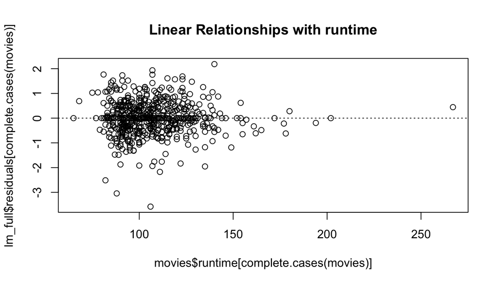

```
## integer(0)
```

```r
lm_full <- lm(imdb_rating ~ title_type + genre + runtime + mpaa_rating + studio
              + thtr_rel_year + thtr_rel_month + thtr_rel_day + dvd_rel_year
              + dvd_rel_month + dvd_rel_day + best_actor_win + best_actress_win
              + best_dir_win, data = movies)

plot(lm_full$residuals[complete.cases(movies)] ~ movies$runtime[complete.cases(movies)])
  abline(0, 0, lty = 3) +
  title("Linear Relationships with runtime")
```

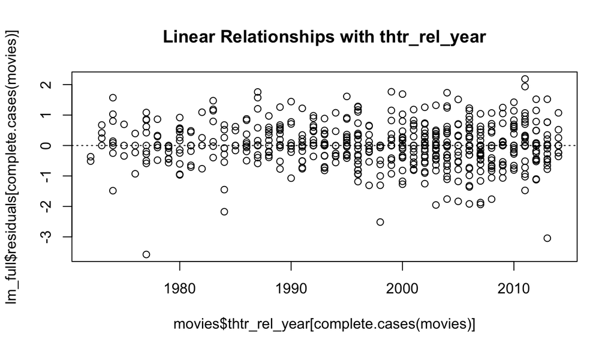

```
## integer(0)
```

```r
plot(lm_full$residuals[complete.cases(movies)] ~ movies$thtr_rel_year[complete.cases(movies)])
  abline(0, 0, lty = 3) +
  title("Linear Relationships with thtr_rel_year")
```

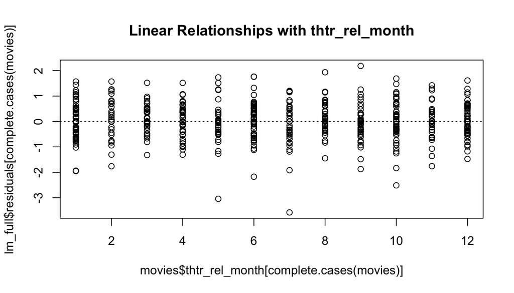

```
## integer(0)
```

```r
plot(lm_full$residuals[complete.cases(movies)] ~ movies$thtr_rel_month[complete.cases(movies)])
  abline(0, 0, lty = 3) +
  title("Linear Relationships with thtr_rel_month")
```

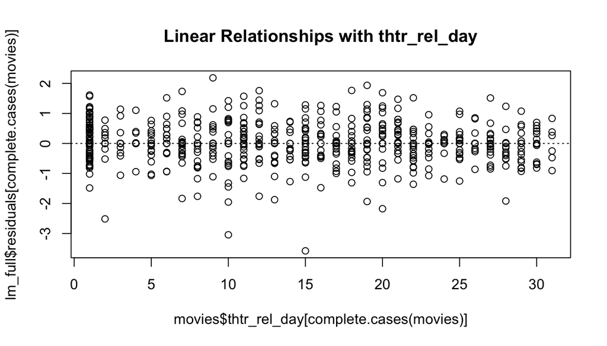

```
## integer(0)
```

```r
plot(lm_full$residuals[complete.cases(movies)] ~ movies$thtr_rel_day[complete.cases(movies)])
  abline(0, 0, lty = 3) +
  title("Linear Relationships with thtr_rel_day")
```

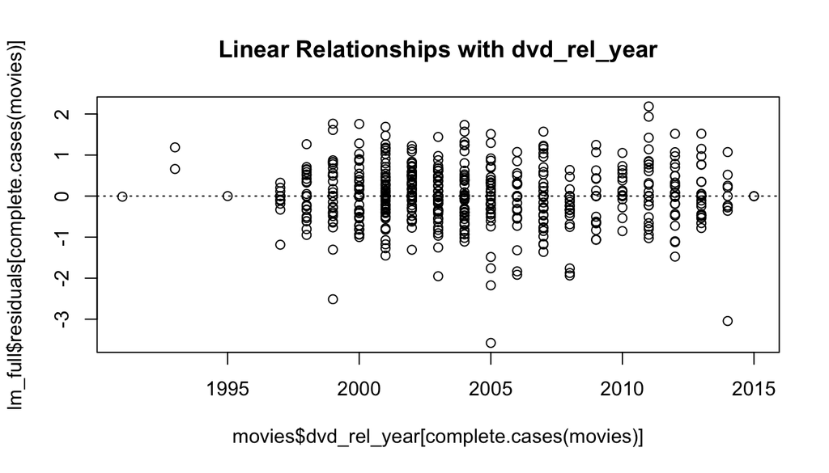

```
## integer(0)
```

```r
plot(lm_full$residuals[complete.cases(movies)] ~ movies$dvd_rel_year[complete.cases(movies)])
  abline(0, 0, lty = 3) +
  title("Linear Relationships with dvd_rel_year")
```

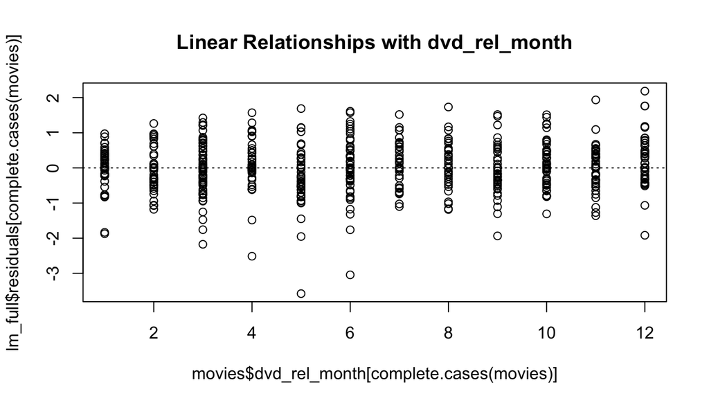

```
## integer(0)
```

```r
plot(lm_full$residuals[complete.cases(movies)] ~ movies$dvd_rel_month[complete.cases(movies)])
  abline(0, 0, lty = 3) +
  title("Linear Relationships with dvd_rel_month")
```

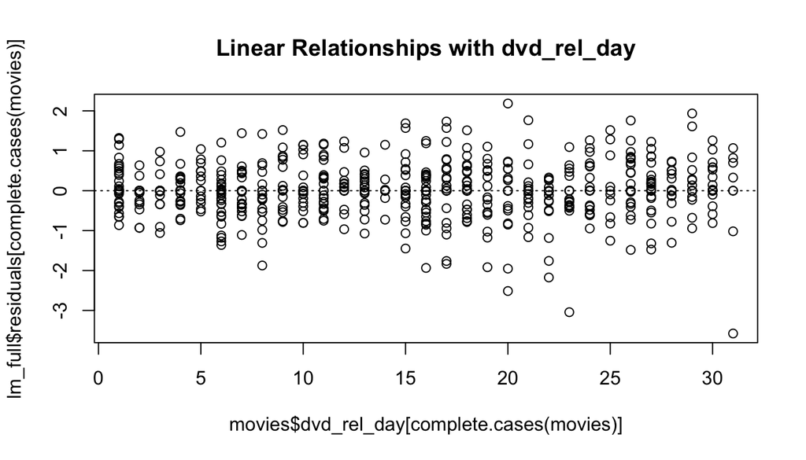

```
## integer(0)
```

```r
plot(lm_full$residuals[complete.cases(movies)] ~ movies$dvd_rel_day[complete.cases(movies)])
  abline(0, 0, lty = 3) +
  title("Linear Relationships with dvd_rel_day")
```

There seems to be no relationships between the numerical variables and the response variable. There is a random scatter around 0 for every plot above. Hence, we can consider all the above variables in our analysis.

2. Nearly Normal Residuals

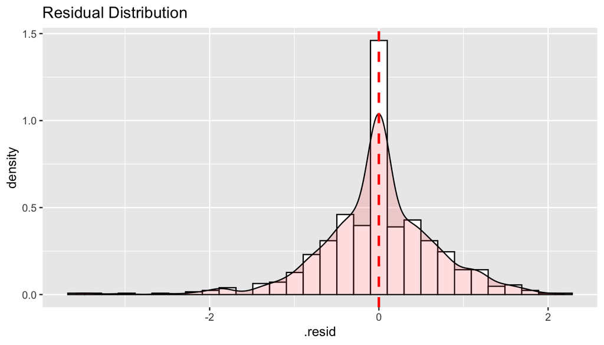

```r
ggplot(lm_full, aes(x=.resid)) +
  geom_histogram(aes(y=..density..), color="black", fill="white") +
  geom_density(alpha=0.2, fill="#FF6666") +
  geom_vline(aes(xintercept=mean(lm_full$residuals)), col = 'red', lwd = 1, lty = 2) +
  ggtitle("Residual Distribution")
```

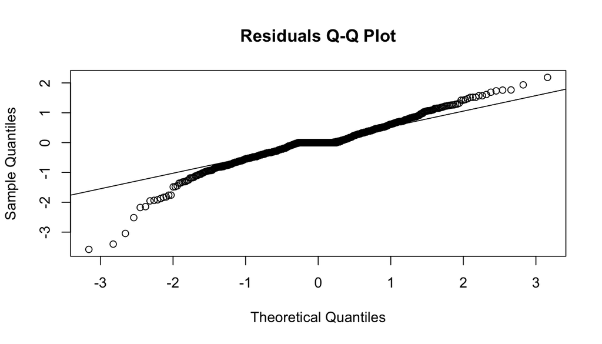

```r
qqnorm(lm_full$residuals, main = "Residuals Q-Q Plot")
qqline(lm_full$residuals)
```

The residuals are fairly symmetric, with only a slightly longer tail on the left, hence it would be appropriate to deem the the normal distribution of residuals condition met.

3. Constant variability of residuals

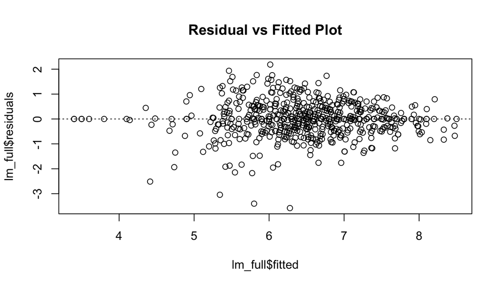

```
## integer(0)
```

```r
plot(lm_full$residuals ~ lm_full$fitted) +
  abline(0, 0, lty = 3) +
  title("Residual vs Fitted Plot")
```

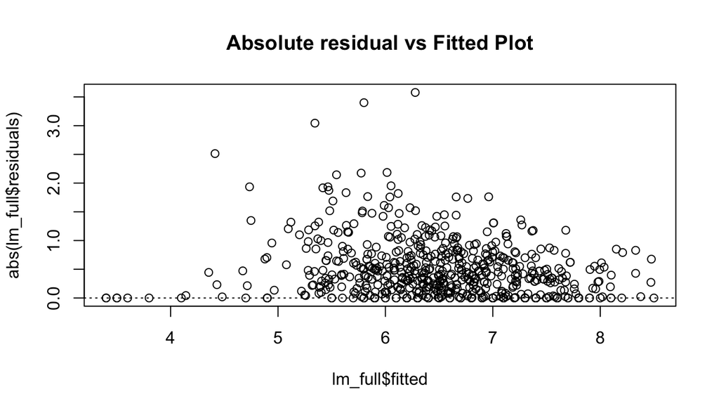

```
## integer(0)
```

```r
plot(abs(lm_full$residuals) ~ lm_full$fitted) +
  abline(0, 0, lty = 3) +
  title("Absolute residual vs Fitted Plot")
```

The absolute value of the residuals don’t follow a triangle and the scatter is spread above and below the mean. It’s safe to say homoscedasticity is present and the variability of the residuals is constant.

4. Independent residuals

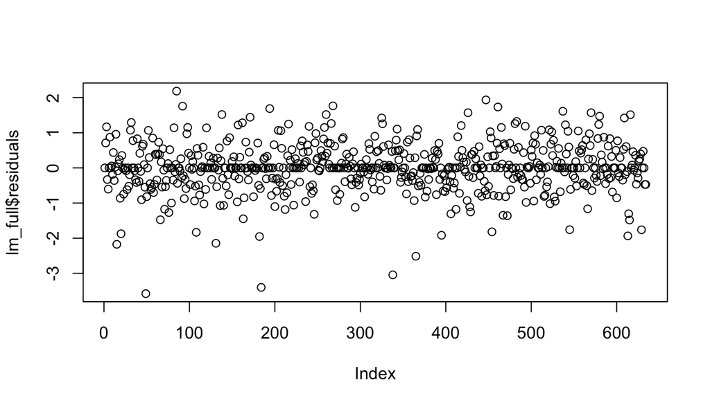

```r
plot(lm_full$residuals)
```

There is no intrinsic ordering present in the residuals and no relation present in the graph above, hence we can say that the residuals are independent of each other.

## Part 4: Modeling

### Variable Selection

The explanatory variables of interest in our analysis are as follows:

| Column | Description |
| --- | --- |
| title_type | Type of movie (Documentary, Feature Film, TV Movie) |
| genre | Genre of movie (Action & Adventure, Comedy, Documentary, Drama, Horror, Mystery & Suspense, Other) |
| runtime | Runtime of movie (in minutes) |
| mpaa_rating | MPAA rating of the movie (G, PG, PG-13, R, Unrated) |
| studio | Studio that produced the movie |
| thtr_rel_year | Year the movie is released in theaters |
| thtr_rel_month | Month the movie is released in theaters |
| thtr_rel_day | Day of the month the movie is released in theaters |
| dvd_rel_year | Year the movie is released on DVD |
| dvd_rel_month | Month the movie is released on DVD |
| dvd_rel_day | Day of the month the movie is released on DVD |
| best_actor_win | Whether or not one of the main actors in the movie ever won an Oscar (no, yes) – note that this is not necessarily whether the actor won an Oscar for their role in the given movie |
| best_actress win | Whether or not one of the main actresses in the movie ever won an Oscar (no, yes) – not that this is not necessarily whether the actresses won an Oscar for their role in the given movie |
| best_dir_win | Whether or not the director of the movie ever won an Oscar (no, yes) – not that this is not necessarily whether the director won an Oscar for the given movie |

This analysis will not consider the following as explanatory variables. These correspond to so some form of ratings or ranking on Imdb, rotten tomatoes or BoxOfficeMojo:

- `imdb_num_votes`: Number of votes on IMDB
- `critics_rating`: Categorical variable for critics rating on Rotten Tomatoes (Certified Fresh, Fresh, Rotten)
- `critics_score`: Critics score on Rotten Tomatoes
- `audience_rating`: Categorical variable for audience rating on Rotten Tomatoes (Spilled, Upright)
- `audience_score`: Audience score on Rotten Tomatoes
- `top200_box`: Whether or not the movie is in the Top 200 Box Office list on BoxOfficeMojo (no, yes)
- `best_pic_nom`: Whether or not the movie was nominated for a best picture Oscar (no, yes)
- `best_pic_win`: Whether or not the movie won a best picture Oscar (no, yes)

Based on domain knowledge, ratings on other websites wouldn’t be available prior to the release of the movie and such variables are likely to have high collinearity with the response variable which will result in incorrect estimators for other factors in this analysis. We can use the a pairplot to verify our assumption:

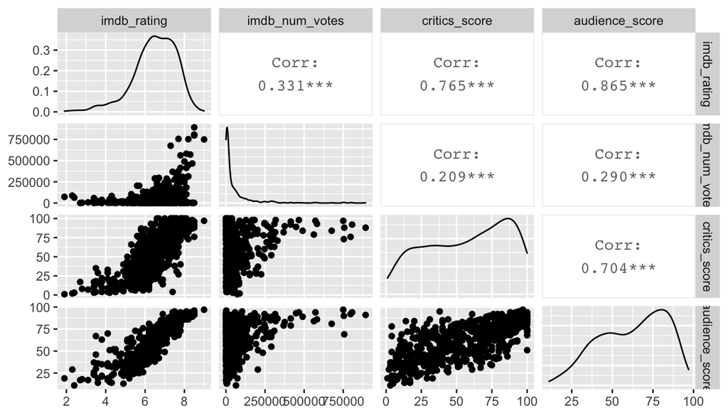

```r
# numerical variables
ggpairs(movies, columns = c('imdb_rating','imdb_num_votes','critics_score','audience_score'))
```

As mentioned earlier, some numerical rating variables such as `audience_score` and `critics_score` on rotten tomatoes tend to result in a high correlation coefficient. Thus, they have a strong linear association with the response variable, which could result in biased estimators for other variables. Furthermore, these variables won’t be available to us prior to the release of a movie.

In terms of categorical variables, we can use ANOVA to verify if the variability in the response variable, `imbd_rating`, can be explained by each of the categorical rating variables.

In order to verify ANOVA conditions:

```r
movies %>%
  group_by(critics_rating) %>%
  summarize(n())
```

```
## # A tibble: 3 x 2
##   critics_rating  `n()`
##   <fct>           <int>
## 1 Certified Fresh   135
## 2 Fresh             209
## 3 Rotten            307
```

```r
movies %>%
  group_by(audience_rating) %>%
  summarize(n())
```

```
## # A tibble: 2 x 2
##   audience_rating `n()`
##   <fct>           <int>
## 1 Spilled           275
## 2 Upright           376
```

```r
movies %>%
  group_by(top200_box) %>%
  summarize(n())
```

```
## # A tibble: 2 x 2
##   top200_box `n()`
##   <fct>      <int>
## 1 no           636
## 2 yes           15
```

1. Independence:
   - within groups: Sampled observations in each group can be assumed independent of every other group. Furthermore, each customer can only give one rating. Each group has less than 10% of the population based on the results in the tables above.
   - between groups: one must be vary of audience and critic ratings since a critic could rate a movie as an audience and vice versa.
2. Approximately normality: distribution of each group must be nearly normal.

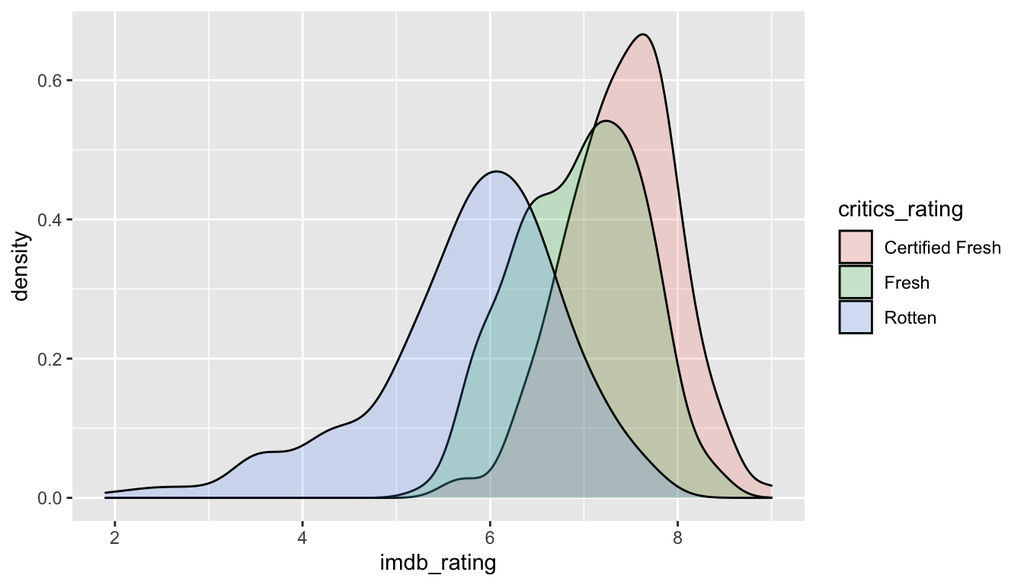

```r
movies %>%
  group_by(critics_rating) %>%
  ggplot(aes(x = imdb_rating, fill=critics_rating)) +
  geom_density(alpha=.2)
```

The distributions of the response variables for each `critics_rating` are nearly normal, even though there’s a left skew.

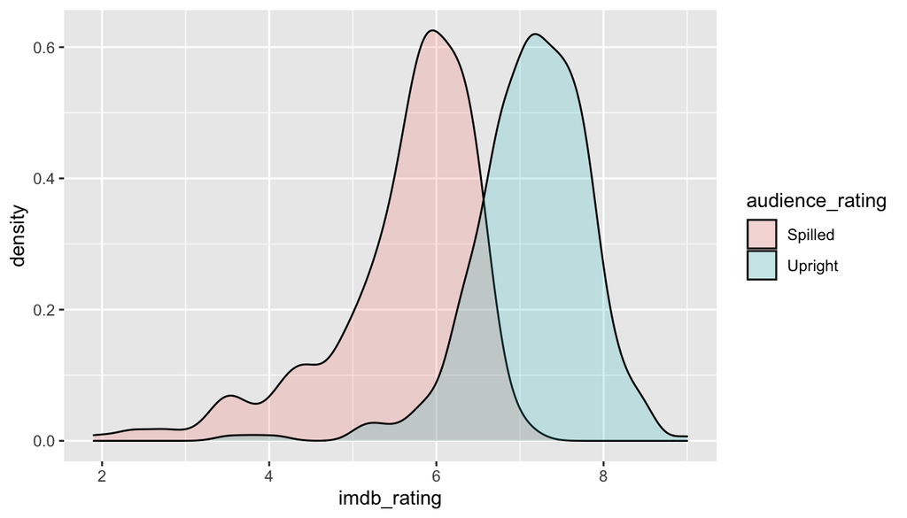

```r
movies %>%
  group_by(audience_rating) %>%
  ggplot(aes(x = imdb_rating, fill=audience_rating)) +
  geom_density(alpha=.2)
```

The distributions of the response variables for each `audience_rating` are nearly normal, even though there’s a left skew.

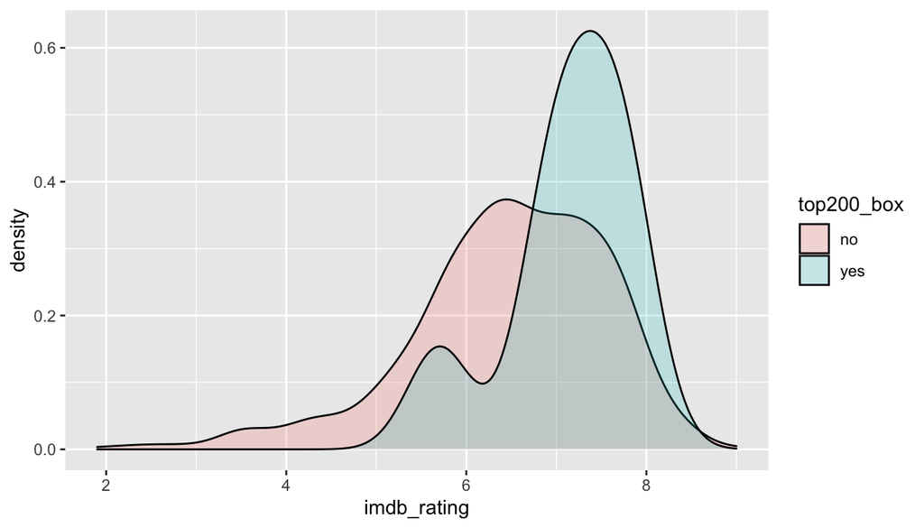

```r
movies %>%
  group_by(top200_box) %>%
  ggplot(aes(x = imdb_rating, fill=top200_box)) +
  geom_density(alpha=.2)
```

The distributions of the response variables for each `top200_box` are nearly normal, even though there’s a left skew.

3. Equal Variance: Groups should have roughly equal variability.

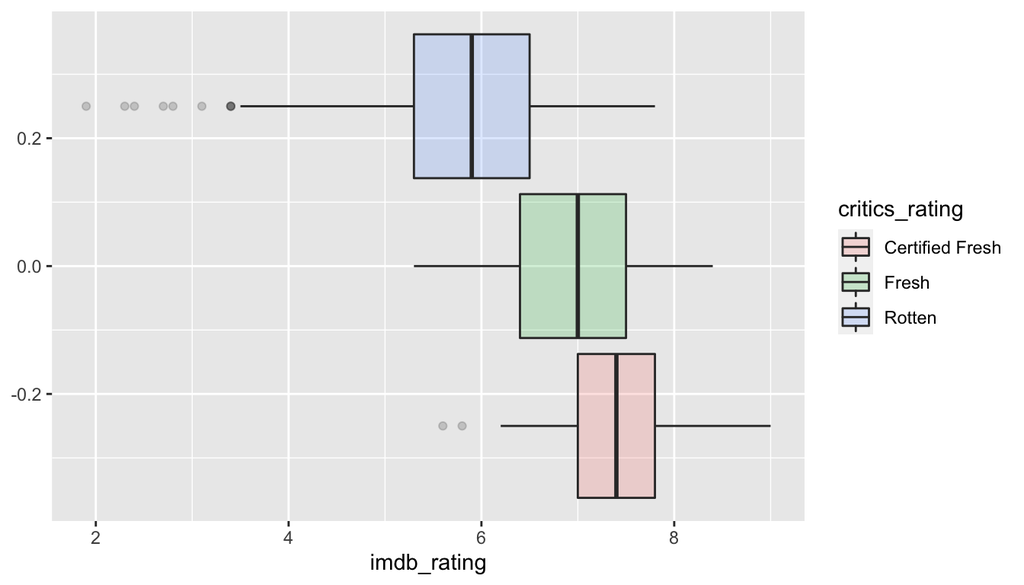

```r
movies %>%
  group_by(critics_rating) %>%
  ggplot(aes(x = imdb_rating, fill=critics_rating)) +
  geom_boxplot(alpha=.2)
```

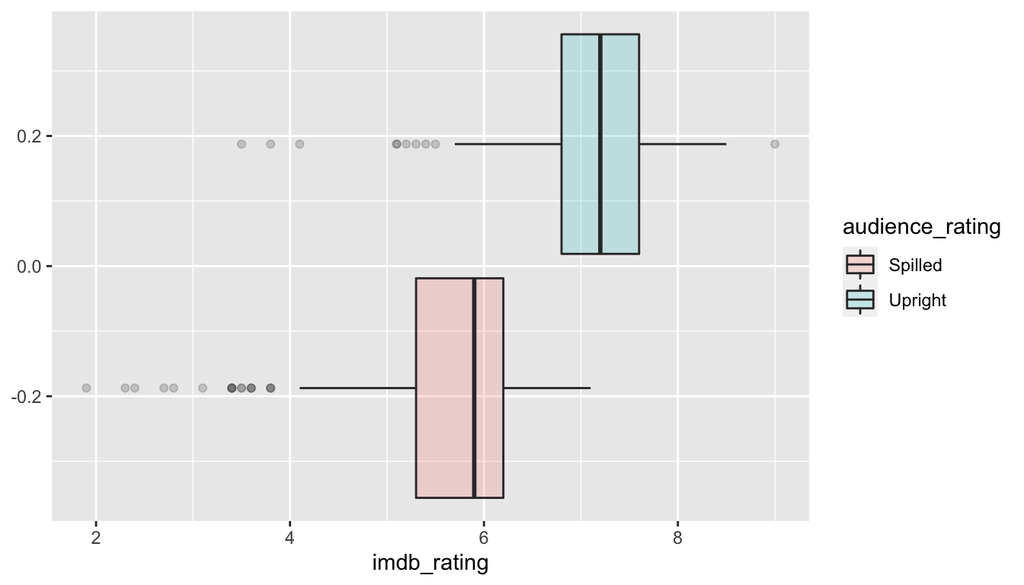

```r
movies %>%
  group_by(audience_rating) %>%
  ggplot(aes(x = imdb_rating, fill=audience_rating)) +
  geom_boxplot(alpha=.2)
```

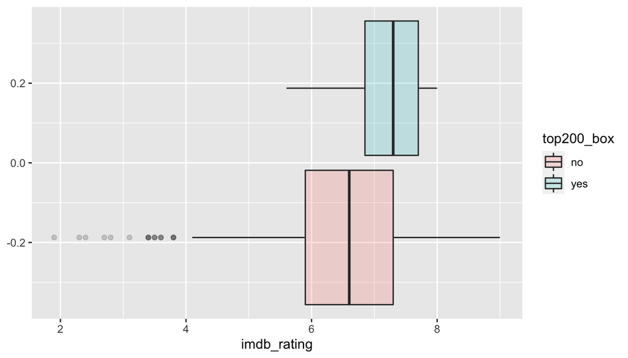

```r
movies %>%
  group_by(top200_box) %>%
  ggplot(aes(x = imdb_rating, fill=top200_box)) +
  geom_boxplot(alpha=.2)
```

Based on the boxplots above, the variability between groups is roughly equal.

We can hence run ANOVA:

```r
cat_aov <- aov(imdb_rating ~ critics_rating + audience_rating + top200_box, data = movies)
summary(cat_aov)
```

```
##                  Df Sum Sq Mean Sq F value Pr(>F)
## critics_rating    2  309.3  154.65  313.08 <2e-16 ***
## audience_rating   1  136.4  136.39  276.12 <2e-16 ***
## top200_box        1    0.0    0.03    0.07  0.792
## Residuals       646  319.1    0.49
## ---
## Signif. codes:  0 '***' 0.001 '**' 0.01 '*' 0.05 '.' 0.1 ' ' 1
```